# Mappeevaluering på SOK-2011 Bærekraftig økonomisk vekst

Mappeoppgave 1 og 2

Author

Andrea Mannberg

Kurset sok-2011 har to innleveringer som sammen vil lage en hovedoppgave på temaet økonomisk vekst. Hovedoppgaven skal inneholde en teoretisk og empirisk analyse og diskusjon av bestemmelsesfaktorer for økonomisk vekst.Hovedoppgaven vil ha en lignende struktur som en Bachelor-oppgave. Hovedoppgaven skal ikke overskride 5000 ord (eksklusive referanser og ekstramateriale). Mappeoppgave 1 består av å skrive de innledende tre seksjonene i hovedoppgaven; 1. Introduksjon, 2. Teori, og 3. Metode og data). Mappeoppgave 2 består av å gjennomføre den empiriske analysen og skrive de siste to seksjonene i hovedoppgaven; 4. Resultat, og 5. Diskusjon. Du velger selv i hvilket format du ønsker å lage oppgaven. Dersom du ønsker å skrive oppgaven i Quarto finner du støtte til dette [her](https://quarto.org/).

I dette hjelpedokumentet vil jeg beskrive **hva** du skal gjøre i innleveringsoppgave 1 og 2, og **hvordan** du skal gjøre dette. Dokumentet har samme disposisjon som din hovedoppgave skal ha når du er klar. Hver seksjon beskriver hva dette avsnittet skal inneholde.

## 1. Introduksjon

Formålet med introduksjonen er å gi leseren en idé om hva den kan forvente seg dersom den leser hele oppgaven (temaet for oppgaven). Introduksjonen skal i tillegg forklare for leseren hvorfor denne skal bruke tid til å lese videre. Introduksjonsdelen kan med fordel holdes relativt kort. Jeg anbefaler at introduksjonen ikke er lengre enn 800 ord (1.5 - 2 sider).

For å gi leseren en idé om hva den kan forvente må du starte med å beskrive hva du skal gjøre i oppgaven. For at leseren skal forstå hvorfor den skal lese oppgaven må du motivere hvorfor temaet er interessant å se på. For å gjøre dette må du gi en kort bakgrunn og motivere temaet for oppgaven. Starte bakgrunnen med å definere økonomisk vekst. Diskuter hvorfor det kan være interessant å se på økonomisk vekst og hvilke mulige problemer det finnes med å se på økonomisk vekst som en indikasjon på endringer i velferd.

Visualiser gjerne hvordan økonomisk vekst henger sammen med andre mål på velferd, f.eks. forventet levealder. Du kan f eks bruke pakken «gapminder» til dette (du finner eksempler og hjelp [her](https://www.rdocumentation.org/packages/gapminder/versions/0.3.0), og [her](https://www.youtube.com/watch?v=GmEKpKEakmQ)).

## 2. Teori: Solow-modellen

Teori-delen skal gjøre rede for teorien som blir testet i den empiriske analysen. I denne oppgaven skal du forklare Solow-modellen for leseren. Mer spesifikkt skal du gjøre forklare hva og hvordan materiell velferd og økonomisk vekst blir bestemt i det lange løp. Forklar i tekst og illustrer grafisk. Vær nøye med å gi økonomisk intuisjon. Det er ikke lov å gjenbruke figurer fra andre kilder.

Avslutte teori-seksjonen med å oppsummere prediksjonene fra den teoretiske modellen.´

## 3. Metode og data

I avsnitt 3 skal du beskrive hvilke data du har brukt i analysen din, og hvilken metode du brukte for å analysere datamaterialet.

### 3.1 Data

I avsnitt 3.1 skal du beskrive de data du har brukt for din analyse. I den her oppgaven skal du bruke data fra [World Development Indicators](https://datatopics.worldbank.org/world-development-indicators/), fra Verdens Banken. Datamaterialet er tilgjengelig i Rstudio via pakken «wdi».

Du finner en beskrivelse av variablene i kapittel 7 i Hess (2016), og ved å bruke søkefunksjonen i wdi-pakken. Jeg har hentet ut de variabler som dere trenger til analysen og satt sammen et datasett. Jeg beskriver hvordan dere får fram datasettet her nede. Du får gjerne bruke egen kode. Du finner hjelp til variablene som finnes i WDI-pakken [her](https://databank.worldbank.org/metadataglossary/all/series) og hvordan du kan lage grafer og analysere data [her](https://worldpoliticsdatalab.org/tutorials/data-wrangling-and-graphing-world-bank-data-in-r-with-the-wdi-package/).

For å lage datasettet vil du trenge følgende pakker:

```r
suppressPackageStartupMessages(library(WDI))
suppressPackageStartupMessages(library(dplyr))
suppressPackageStartupMessages(library(plyr))
suppressPackageStartupMessages(library(tidyverse))
suppressPackageStartupMessages(library(countrycode))
```

Vi vil bruke følgende variabler fra WDI:

```r
#   NY.GDP.PCAP.PP.KD (gdppc) = BNP per innbygger (PPP)
#   NY.ADJ.NNAT.GN.ZS (nsy) = Sparing som andel av BNI (netto)
#   SP.POP.TOTL (poptot) = Befolkningsstørrelse
#   JI.TLF.TOTL (lf) = Størrelse på arbeidskraften
#   SP.POP.GROW (p) = Vekstrate i befolkningen
#   BAR.SCHL.15UP (educ) = Gjennomsnittlig antall år i skole (befolkning 15+)
#   NE.GDI.FTOT.KD.ZG (gi) = Årlig vekstrate i investeringer
#   NE.EXP.GNFS.KD.ZG (gx) = Årlig vekstrate i eksport
#   NY.ADJ.DRES.GN.ZS (nry) = Årlig reduksjonsrate i naturressurser
```

Du kan lere mer om variablene ved å bruke søkefunksjonen i WDI-pakken

```r
# WDIsearch(string = "search item", field = "name", short = TRUE, cache = NULL)
```

Det er mulig å laste ned alle variabler på en gang. Dette tar dessverre lang tid. I tillegg ønsker vi å lage noen nye variabler. For å få bedre oversikt over datamaterialet og minke tidsbruken har jeg valgt å laste ned noen av variablene separat.

```r
# 1. BNP per innbyggere (alle år) og initial nivå på BNP per innbyggere. WDI-variabel =  "NY.GDP.PCAP.PP.KD".
# Velg startår = 2000 og sluttår = 2019
df_gdp0<-WDI(
  country = "all",
  indicator = c('gdppc'="NY.GDP.PCAP.PP.KD"),
  start = 2000,
  end = 2019,
  extra = TRUE, # det å sette "extra = TRUE" fører til at vi laster inn ekstra informasjon som vi kan benytte seinere (f.eks. variabelen "region")
  cache = NULL,
  latest = NULL,
  language = "en"
)

df_gdp <- subset(df_gdp0, select = c(country, region, income, iso2c, iso3c, year, gdppc) ) %>%  arrange(iso3c, year) # velg ut relevante variabler
df_gdp <-  df_gdp %>% mutate_all(na_if,"") # Vi ønsker å ta vekk land som ikke har en iso3c kode. Dessverre er manglende observasjoner for "iso3c" (landkode) kodet som "blanks" isteden for "missing". Denne koden korrigerer dette.
df_gdp <- df_gdp[complete.cases( df_gdp$gdppc, df_gdp$iso3c),] # Ta vekk observasjoner som mangler data på gdppc og iso3c.
df_gdp = df_gdp  %>%
  mutate(year = as.numeric(year)) # Se til at year er en numerisk variabel.

# Noen land har flere observasjoner for samme år (f.eks afghanistan år 2010). Vi ønsker å ha én observasjon per land og år.
df_gdp <- df_gdp[!duplicated(df_gdp[c("iso3c", "year", max("gdppc"))]), ]  %>%  arrange(iso3c, year) # Ta vekk duplikater for land og år, behold observasjonen med størst gdppc (denne regelen kan diskuteres)

# Lag et datasett med Y0 (nivå på BNP per innbyggere i år 2000)
df_gdp2000  <- df_gdp %>%  arrange(iso3c, year) %>% group_by(iso3c) %>% #Behold den første observasjonen for BNP per innbyggere (Y0)
  slice(1) %>%
  ungroup()
df_gdp2000 = subset(df_gdp2000, select = -c(year) ) # Slett unødvendige variabler
df_gdp2000 <-   plyr:: rename(df_gdp2000,c("gdppc" = "gdppc0")) # Gi variabeln et nytt navn slik at vi kan identifisere den i datasetet.

df_gdp <- left_join(df_gdp,df_gdp2000, by=c("country", "iso2c", "iso3c", "region", "income")) # Sett sammen data for BNP per innbygger alle år, med BNP per innbygger år 2000.
```

```r
# 2. Humankapital (gjennomsnittlig antall år i skole blant befolkningen eldre enn 15 år). WDI-variabel = BAR.SCHL.15UP
df_educ0<-WDI(
  country = "all",
  indicator = c('educ'="BAR.SCHL.15UP"),
  start = 2000,
  end = 2019,
  extra = TRUE,
  cache = NULL,
  latest = NULL,
  language = "en"
)

df_educ <- subset(df_educ0, select = c(country, region, income, iso2c, iso3c, year, educ) ) %>%  arrange(iso3c, year) #Behold nødvendige variabler
df_educ <- df_educ[complete.cases(df_educ$educ),] %>%  arrange(iso3c, year) # Slett observasjoner med manglende data

df_educ = df_educ %>%
  arrange(iso3c, year) %>%  # Sorter etter Iso-kode og år.
  mutate(educ = as.numeric(educ, na.rm = TRUE)) %>% # Se til at variabelen er numerisk
  ddply("iso3c",transform,
        avg_educ=mean(educ, na.rm = TRUE))  # Beregne gjennomsnittlig år i skole for tidsperioden 2000 - 2019 for hvert land, basert på tilgjenglig data (vil være 2000.2005,2010)

df_educ <- subset(df_educ, select = c(country, region, income, iso2c, iso3c, avg_educ)) # Her tar jeg vekk variabelen "year". Jeg gjør dette fordi vi bare har en observasjon på utdanning per land. Vi ønsker å bruke denne verdi for alle år.
df_educ <- df_educ[!duplicated(df_educ[c("iso3c")]), ]  %>%  arrange(iso3c) # Ta vekk duplikater for hvert land.
```

```r
# 3. Gjennomsnittlig sparing for perioden 2000-2015 (lagg fordi det kan ta litt tid for sparing å bli til investering)
df_nsy0<-WDI(
  country = "all",
  indicator = c( 'nsy'="NY.ADJ.NNAT.GN.ZS"),
  start = 2000,
  end = 2015,
  extra = TRUE,
  cache = NULL,
  latest = NULL,
  language = "en"
)

df_nsy <- subset(df_nsy0, select = c(country, region, income, iso2c, iso3c, year, nsy) ) %>%  arrange(iso3c, year) #Behold nødvendige variabler
df_nsy <- df_nsy[complete.cases(df_nsy$nsy),] %>%  arrange(iso3c, year) # Slett observasjoner med manglende data


df_nsy = df_nsy %>%
  arrange(iso3c, year) %>%  # Sorter etter Iso-kode og år.
  mutate(nsy = as.numeric(nsy, na.rm = TRUE)) %>% # Se til at variabelen er numerisk
  ddply("iso3c",transform,
        avg_nsy=mean(nsy, na.rm = TRUE))  # Beregne gjennomsnittlig år i skole for tidsperioden 2000 - 2019 for hvert land, basert på tilgjenglig data (vil være 2000.2005,2010)

df_nsy <- subset(df_nsy, select = c(country, region, income, iso2c, iso3c, avg_nsy)) # Her tar jeg vekk variabelen "year". Jeg gjør dette fordi vi bare har en observasjon på utdanning per land. Vi ønsker å bruke denne verdi for alle år.
df_nsy <- df_nsy[!duplicated(df_nsy[c("iso3c")]), ]  %>%  arrange(iso3c) # Ta vekk duplikater for hvert land.
```

```r
# 4. Vekst i arbeidskraften (n)
df_lf0<-WDI(
  country = "all",
  indicator = c('lf'="JI.TLF.TOTL"),  # lf = labor force
  start = 2000,
  end = 2019,
  extra = TRUE,
  cache = NULL,
  latest = NULL,
  language = "en"
)

df_lf <- subset(df_lf0, select = c(country, region, income, iso2c, year, lf) ) %>%  arrange(iso2c, year) # velg ut relevante variabler
df_lf <-   plyr:: rename(df_lf,c("iso2c" = "iso3c")) # variabelen som identifiserer land med kode er feil i datasetet. Dette korrigerer dette
df_lf <-  df_lf %>% mutate_all(na_if,"")
df_lf [df_lf == 0]<-NA
df_lf <- df_lf[complete.cases(df_lf$iso3c, df_lf$lf),] # Ta vekk observasjoner som mangler data på lf og iso3c.
df_lf = df_lf  %>%
  mutate(year = as.numeric(year)) # Se til at year er en numerisk variabel.

df_lf <- df_lf[!duplicated(df_lf[c("iso3c", "year")]), ]  %>%  arrange(iso3c, year) # Ta vekk duplikater for land og år

# Ta fram vekstraten i arbeidskraften (n). Vi har ikke data for hvert år i alle land.
# For å beregne gjennomsnittlig årlig vekst må vi lage en variabel som måler antallet tidsperioder mellom hver observasjon.
df_n = df_lf %>%
  arrange(iso3c, year) %>%  # Sorter på år og land
  ddply("iso3c",transform,
        t=c(NA,diff(year)),
        lf_growth=c(NA,diff(log(lf)))) #Vekstrate uten hensyn til tidsintervall

df_n <- df_n[complete.cases(df_n$t, df_n$lf_growth),] # Ta vekk observasjoner som mangler data på t

#Nå kan vi ta fram årlig vekstrate
df_n = df_n %>%
        mutate(t = as.numeric(t)) %>%
        mutate(lf_growth = as.numeric(lf_growth))
df_n <- transform(df_n, n =lf_growth/t)

# gjennomsnittlig vekstrate i arbeidskraften for hvert land
df_n <- df_n %>% #
          ddply("iso3c",transform,
                avg_n=mean(n, na.rm = TRUE)) #Gjennomsnittlig årlig vekstrate i arbeidskraften

df_n <- subset(df_n, select = c(iso3c, avg_n) )
df_n <- df_n[!duplicated(df_n["iso3c"]), ]  %>%  arrange(iso3c) # Ta vekk duplikater for land
```

```r
# 5. Lag et datasett som inneholder BNP data, utdanningsdata, sparing, og arbeidskraftsdata

df <- left_join(df_gdp, df_educ, by=c("country", "iso2c", "iso3c", "region", "income"))
df <- left_join(df, df_nsy, by=c("country", "iso2c", "iso3c", "region", "income"))
df <- left_join(df, df_n, by="iso3c")
df <- subset(df, select = c(country, region, income, iso2c, iso3c, year, gdppc, gdppc0, avg_educ, avg_nsy, avg_n)) # Behold nødvendige variabler

# Mange observasjoner representerer aggregerte regioner. Vi ønsker å ta vekk disse. Det finnes helt sikkert en bedre måte å gjøre dette på. Dette er den måten jeg kom på.
df <- df  %>%  filter(iso2c!='1A' & iso2c !='1W' & iso2c != '4E' & iso2c != '7E' & iso2c !='8S'
                                         & iso2c !='B8' & iso2c !='EU' & iso2c !='F1' & iso2c !='OE' & iso2c !='S1' & iso2c !='S2' & iso2c !="S3"
                                         & iso2c !='S4' & iso2c !='T2' & iso2c !='T3' & iso2c !='T4' & iso2c !='T5' & iso2c !='T6' & iso2c !='T7'
                                         & iso2c !='V1' & iso2c !='V2' & iso2c !='V3' & iso2c !='V4' & iso2c !='XC' & iso2c !='XD' & iso2c !='XE'
                                         & iso2c !='XF' & iso2c !='XG' & iso2c !='XH' & iso2c !='XI' & iso2c !='XJ' & iso2c !='XL' & iso2c !='XM'
                                         & iso2c !='XN' & iso2c !='XO' & iso2c !='XP' & iso2c !='XQ' & iso2c !='XT' & iso2c !='XU' & iso2c !='Z4'
                                         & iso2c !='Z7' & iso2c !='ZF'& iso2c !='ZG'  & iso2c !='ZH' & iso2c !='ZI'  & iso2c !='ZJ'  & iso2c !='ZQ'
                                         & iso2c !='ZT'  & iso2c !='Z7')  %>% arrange(iso3c, year)
```

```r
# 6. Lag et datasett for resterende variabler.

df_rest0<-WDI(
  country = "all",
  indicator = c('poptot'="SP.POP.TOTL", 'gi'="NE.GDI.FTOT.KD.ZG", 'gx'="NE.EXP.GNFS.KD.ZG", 'nry'="NY.ADJ.DRES.GN.ZS", 'p'="SP.POP.GROW" ),
  start = 2000,
  end = 2019,
  extra = TRUE,
  cache = NULL,
  latest = NULL,
  language = "en"
)

df_rest0<-df_rest0 %>% mutate_all(na_if,"")
df_rest <- df_rest0[complete.cases( df_rest0$iso3c),]  %>%  arrange(iso2c)


# Ta vekk observasjoner som ikke representerer land.
df_rest <- df_rest  %>%  filter(iso2c!='1A' & iso2c !='1W' & iso2c != '4E' & iso2c != '7E' & iso2c !='8S'
                                  & iso2c !='B8' & iso2c !='EU' & iso2c !='F1' & iso2c !='OE' & iso2c !='S1' & iso2c !='S2' & iso2c !="S3"
                                  & iso2c !='S4' & iso2c !='T2' & iso2c !='T3' & iso2c !='T4' & iso2c !='T5' & iso2c !='T6' & iso2c !='T7'
                                  & iso2c !='V1' & iso2c !='V2' & iso2c !='V3' & iso2c !='V4' & iso2c !='XC' & iso2c !='XD' & iso2c !='XE'
                                  & iso2c !='XF' & iso2c !='XG' & iso2c !='XH' & iso2c !='XI' & iso2c !='XJ' & iso2c !='XL' & iso2c !='XM'
                                  & iso2c !='XN' & iso2c !='XO' & iso2c !='XP' & iso2c !='XQ' & iso2c !='XT' & iso2c !='XU' & iso2c !='Z4'
                                  & iso2c !='Z7' & iso2c !='ZF'& iso2c !='ZG'  & iso2c !='ZH' & iso2c !='ZI'  & iso2c !='ZJ'  & iso2c !='ZQ'
                                  & iso2c !='ZT'  & iso2c !='Z7')  %>% arrange(iso3c, year)

df_rest <- subset(df_rest, select = c("country", "region", "income", "iso3c", "iso2c", "year", "poptot", "p", "nry", "gi", "gx"))
df_all <- left_join(df, df_rest, by=c("country", "region", "income", "iso2c", "iso3c", "year"))

# Lag en rekkefølge til variablene slik at det er enklere å få en oversikt over datamaterialet.
col_order <- c("country",  "region", "income", "iso3c", "iso2c", "year", "gdppc", "gdppc0", "poptot", "p", "avg_n", "avg_nsy", "nry", "gi", "gx", "avg_educ")
df_all <- df_all[, col_order]
```

```r
# Ta fram vekstraten og gjennomsnitt for resterende variabler
df_growth0 = df_all %>%
  arrange(iso3c, year) %>%  # Sorter på år og land
  ddply("iso3c",transform,
        gdpgrowth=c(NA,diff(log(gdppc)))*100) %>%   # Årlig vekstrate i gdppc for hvert land
  mutate(gdpgrowth = as.numeric(gdpgrowth, na.rm = TRUE)) %>% #
  ddply("iso3c",transform,
        avg_gdpgrowth=mean(gdpgrowth, na.rm = TRUE), #Gjennomsnittlig årlig vekstrate i BNP per innbygger for hvert land i perioden
        avg_gi=mean(gi, na.rm = TRUE), # Gjennomsnittlig årlig vekstrate i investeringer for hvert land  i perioden
        avg_nry=mean(nry, na.rm = TRUE),  # Gjennomsnittlig årlig vekstrate (negativ) i naturressurser for hvert land  i perioden
        avg_gx=mean(gx, na.rm = TRUE),  # Gjennomsnittlig årlig vekstrate i eksport for hvert land  i perioden
        avg_p=mean(p, na.rm = TRUE))  # Gjennomsnittlig årlig vekstrate i befolkningen for hvert land  i perioden

#View(df_growth0)
df_growth0 <-  df_growth0 %>% mutate_all(na_if,"")
df_growth <- df_growth0[complete.cases( df_growth0$country, df_growth0$income, df_growth0$iso3c, df_growth0$avg_gdpgrowth, df_growth0$gdppc0, df_growth0$avg_n, df_growth0$avg_p, df_growth0$avg_nsy, df_growth0$avg_nry,df_growth0$avg_gi, df_growth0$avg_gx, df_growth0$avg_educ),] # Ta vekk land som mangler data


df_growth <- subset(df_growth, select = c("country",  "region", "income", "iso3c", "iso2c","year", "poptot", "gdppc", "gdppc0", "avg_gdpgrowth", "avg_n", "avg_p", "avg_nsy", "avg_nry", "avg_gi", "avg_gx", "avg_educ"))

# Lage datasettet du vil bruke til analysen din
df_growth2019  <- df_growth %>%  arrange(iso3c, year) %>% group_by(iso3c) %>%
  slice(n()) %>% # Behold den SISTE observasjonen for hvert land
  ungroup()
head(df_growth2019)
```

```
# A tibble: 6 × 17
  country  region income iso3c iso2c  year poptot  gdppc gdppc0 avg_g…¹    avg_n
  <chr>    <chr>  <chr>  <chr> <chr> <dbl>  <dbl>  <dbl>  <dbl>   <dbl>    <dbl>
1 Albania  Europ… Upper… ALB   AL     2019 2.85e6 13656.  5894.   4.42  -0.0229
2 Argenti… Latin… Upper… ARG   AR     2019 4.49e7 22072. 18525.   0.922  0.00225
3 Armenia  Europ… Upper… ARM   AM     2019 2.82e6 14318.  3922.   6.82   0.00945
4 Austral… East … High … AUS   AU     2019 2.53e7 49379. 38495.   1.31   0.0169
5 Austria  Europ… High … AUT   AT     2019 8.88e6 55806. 46470.   0.964  0.00476
6 Belgium  Europ… High … BEL   BE     2019 1.15e7 51977. 43024.   0.995  0.00761
# … with 6 more variables: avg_p <dbl>, avg_nsy <dbl>, avg_nry <dbl>,
#   avg_gi <dbl>, avg_gx <dbl>, avg_educ <dbl>, and abbreviated variable name
#   ¹avg_gdpgrowth
# ℹ Use `colnames()` to see all variable names
```

```r
# Lag en variabel som er logaritmen av BNP per innbygger (enklere tolkning og presser sammen fordelingen)
df_growth2019$dppc <-as.numeric(df_growth2019$gdppc)
df_growth2019$ln_gdppc<-log(df_growth2019$gdppc)
df_growth2019$ln_gdppc0<-log(df_growth2019$gdppc0)
```

### 3.2 Metode

I metodeseksjonen skal du beskrive hvordan du har håndtert og analysert datamaterialet. Beskriv hvilke pakker du har brukt for å lage grafer, og hvilken metode du har brukt for å gjennomføre den økonometriske analysen.

I resultatdelen skal du analysere hvordan vekstraten i BNP per innbygger korrelerer med følgende variabler: gjennomsnittlig netto-sparing, gjennomsnittlig humankapital (år i skole), gjennomsnittlig uttømning av naturressurser, gjennomsnittlig årlig vekst i investeringer, gjennomsnittlig vekstrate i arbeidskraften og gjennomsnittlig vekstrate i befolkningen, gjennomsnittlig vekstrate i eksport, og BNP per innbygger i år 2000.

Du vil analysere sammenhengen mellom vekstraten i BNP per innbygger og de forklarende variablene ved bruk av multippel linjær regresjonsanalyse. For å estimere modellen vil du bruke minste-kvadrat-metoden (OLS). Du trenger ikke å gå inn på detaljene i minste-kvadrat-metoden, men du må skrive at du har brukt denne metoden. I tillegg må du beskrive den ligning som du estimerer ved bruk av metoden.

NB: det ser ut å finnes observasjoner i datamaterialet som har en stor innvirkning på resultatet (“outliers” eller “influential observations”). Du kan lese om hvordan vi kan identifisere disse [her](https://www.r-bloggers.com/2021/09/how-to-remove-outliers-in-r-3/). I avsnitt 4.2 viser jeg et eksempel på hvordan du kan ta vekk disse observasjonene fra din analyse.

Metodedelen avslutter mappeoppgave 1.

## 4. Resultat

Mappeoppgave 2 starter med resultatdelen. I resultatdelen skal du beskrive resultatet av din empiriske analyse. Du må til stor del selv finne ut hva du skal gjøre for å få fram resultatene.

### 4.1 Deskriptiv statistikk

Den deskriptive statistikken har til formål å gi informasjon om datamaterialet og visualisere datamengden. I denne seksjonen vil du ikke teste om det er en statistisk signifikant sammenheng mellom ulike variabler, men du kan vise fram om det ser ut å finnes en korrelasjon.

Avsnittet skal inneholde en tabell som viser gjennomsnittlige verdier, samt min og maks-verdier for alle de variabler som du bruker i den økonometriske analysen. Tabellen skal limes inn i manuskriptet og gis navnet «Tabell 1. Deskriptiv statistikk». Beskriv tabell 1 i teksten.

Du kan lage mer beskrivende navn til variablene og lage tabeller ved bruk av ulike pakker. Her nede bruker jeg “vtable”.

```r
suppressPackageStartupMessages(library(vtable))
```

```r
# Velg ut de variabler du vil ha med i tabellen. Her er et eksempel (du skal ta med alle variabler som du har med i den empiriske analysen)
df <- subset(df_growth2019, select = c("avg_gdpgrowth", "avg_p"))
# Gi beskrivende navn til variablene (i samme rekkefølge som de ligger i datasettet)
labs <- c("Gjennomsnitlig årlig vekstrate i BNP pc 2000-2019 (%)", "Gjennomsnittlig årlig befolkningsvekst (%)")

# Lag tabellen
st(df, labels=labs,
   summ = list(
     c('notNA(x)','mean(x)','sd(x)','min(x)','max(x)'), # Beskriv hvilken statistikk du ønsker å vise
     c('notNA(x)','mean(x)')
   ),
   summ.names = list(
     c('N','Gjennomsnitt','SD','Min','Maks') # Gi navn til kolumnene
  ))
```

Summary Statistics

| Variable | N | Gjennomsnitt | SD | Min | Maks |
| --- | --- | --- | --- | --- | --- |
| Gjennomsnitlig årlig vekstrate i BNP pc 2000-2019 (%) | 98 | 2.463 | 1.723 | -1.167 | 8.43 |
| Gjennomsnittlig årlig befolkningsvekst (%) | 98 | 1.191 | 1.132 | -1.161 | 3.853 |

Du finner flere eksempler på hvordan du lager tabeller i Rstudio [her](https://thatdatatho.com/easily-create-descriptive-summary-statistic-tables-r-studio/) og [her](https://cran.r-project.org/web/packages/vtable/vignettes/sumtable.html).

Avsnitt 4.1 skal også skal inneholde grafer som visualiserer korrelasjoner mellom nivå på og vekst i BNP per innbygger på den ene siden og utvalgte variabler. Lag grafer som viser sammenhengen mellom den **naturlige logaritmen** av BNP per innbygger på den ene siden og 1) sparing, 2) befolkningsvekst og 3) humankapital på den andre siden. Lag også grafer som visualiserer sammenhengen mellom årlig vekstrate i BNP per innbygger på den ene siden, og 4) sparing og 5) utdanning på den andre siden. Beskriv hva grafene viser.

NB: Du må enten lage en ny variabel for den naturlige logaritmen av BNP per innbygger, eller spesifisere at BNP per innbygger skal logaritmeres i koden til grafen. Her nede viser jeg et eksempel der jeg bruker ggplot sammen med pakken “scales”.

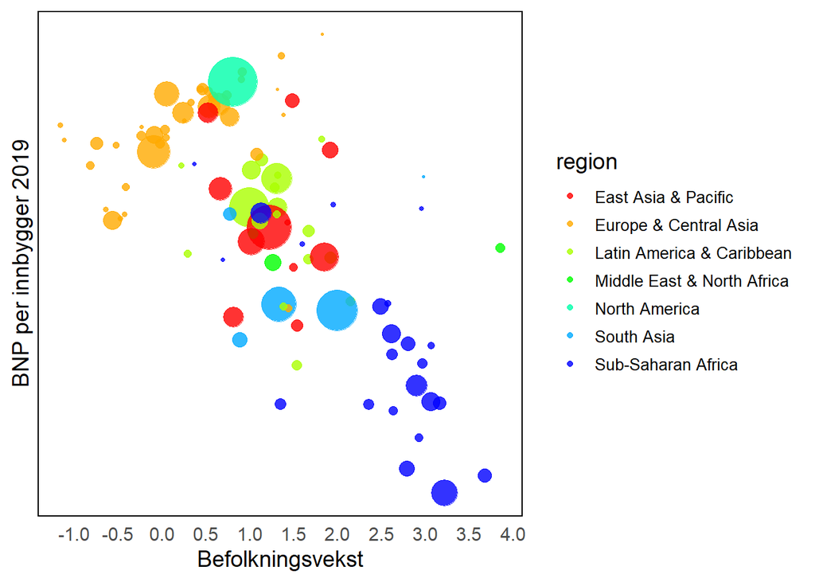

```r
suppressPackageStartupMessages(library(scales))

df_growth2019_n <- df_growth2019[complete.cases(df_growth2019$region,df_growth2019$poptot, df_growth2019$avg_p, df_growth2019$gdppc),] #Her tar jeg vekk land som mangler observasjoner. Dette gjør grafen penere.

plot1 <- ggplot(df_growth2019_n, aes(x = avg_p , y = ln_gdppc, na.rm = TRUE)) +
  xlab("Befolkningsvekst") + # Beskrivelse for x-akselen
  ylab("BNP per innbygger 2019") + # Beskrivelse for y-akselen
  theme_minimal(base_size = 14, base_family = "Georgia") + # Tekststørrelse og font
  geom_point(aes(size = poptot, color = region), alpha = 0.8) + # Størrelse (farge) på bobblene avhenger befolkningsstørrelse (region)
  scale_x_continuous(labels = dollar)  + # Legg til et dollar tegn til y-akselen
  scale_size_area(guide = "none", max_size = 14) + #Ta vekk legend for befolkningsstørrelse
  theme(legend.text = element_text(size = 10,color="black"))+  # Bestem font-størrelse på legend
  scale_colour_manual(values = rainbow(9)) +# Velg farger til bobblene
  theme(panel.grid.major = element_blank(), panel.grid.minor = element_blank(), panel.background = element_rect(fill = 'white'))+
  scale_y_continuous(trans = 'log2', labels = dollar, breaks=c(500, 2000, 8000, 32000, 120000)) + # logaritmere BNP pc og velg hvilke "ticks" som skal vises
  scale_x_continuous(breaks=c(-1, -0.5, 0, 0.5, 1, 1.5, 2, 2.5, 3, 3.5, 4, 4.5, 5 )) # Velg vilke "ticks" som skal vises på x-akselen
plot1
```

### 4.2 Økonometrisk analyse

I avsnitt 4.2 skal du presentere resultatene av din regresjonsanalyse. Lag i en tabell som viser koeffisientene til alle forklarende variabler, signifikans-nivå, og R2-verdi.

NB 1: Det kan være en god ide å starte med en modell der du har med de variabler som den teoretiske modellen er viktigst, for å deretter legge til variabler som også kan være viktige bestemmelsesfaktorer selv om Solow-modellen ikke tar hensyn til disse.

```r
suppressPackageStartupMessages(library(sjPlot))
suppressPackageStartupMessages(library(sjmisc))
suppressPackageStartupMessages(library(sjlabelled))

model1 <- lm(ln_gdppc  ~ avg_educ, data= df_growth2019)
tab_model(model1)
```

|  | ln gdppc |  |  |
| --- | --- | --- | --- |
| Predictors | Estimates | CI | p |
| (Intercept) | 6.93 | 6.59 – 7.27 | **<0.001** |
| avg educ | 0.33 | 0.29 – 0.37 | **<0.001** |
| Observations | 98 |  |  |
| R<sup>2</sup> / R<sup>2</sup> adjusted | 0.737 / 0.734 |  |  |

NB 2: Datamaterialet inneholder noen ekstreme observasjoner (outliers). Du kan identifisere disse ved å bruke koden her nede. Koden lager et datasett der outliers har blitt tatt vekk. Du kan bruke dette datasettet til å estimere nye modeller og sammenligne dine resultater.

```r
df <- df_growth2019[complete.cases( df_growth2019$avg_gi, df_growth2019$avg_n),]

Q1gi <- quantile(df$avg_gi, .25 )
Q3gi <- quantile(df$avg_gi, .75)
IQRgi <- IQR(df$avg_gi)

Q1n <- quantile(df$avg_n, .25 )
Q3n <- quantile(df$avg_n, .75)
IQRn <- IQR(df$avg_n)

no_outliers <- subset(df, df$avg_gi > (Q1gi - 1.5*IQRgi) & df$avg_gi < (Q3gi + 1.5*IQRgi) &  df$avg_n > (Q1n - 1.5*IQRn) & df$avg_n < (Q3n + 1.5*IQRn))
dim(no_outliers)
```

```
[1] 91 20
```

Beskriv effekten av de ulike variablene på vekst i BNP per innbygger. Er f.eks. en høyere sparerate knyttet til en høyere eller lavere vekst i BNP per innbygger? Er effekten signifikant? Beskriv i tillegg i hvor godt dine forklaringsvariabler klarer å forklare vekstraten i BNP per innbygger.

## 5. Diskusjon

I diskusjonen skal du tolke og diskutere dine resultater. I diskusjonen skal du besvare følgende spørsmål: Støtter resultatene prediksjonene fra Solow-modellen? Hva betyr resultatene? Hvilke konklusjoner kan vi dra fra den empiriske analysen? Finnes det noen problemer med analysen eller datamaterialet som fører til at vi kanskje ikke burde dra for sterke konklusjoner?

Til slutt skal du diskutere implikasjoner for policy (politiske inngrep). Basert på din analyse, hva ville du anbefale at politiker, som ønsker å oppnå bærekraftig vekst, skal føre for politikk?

## Referanser

I referanseavsnittet skal du oppgi de referanser du har brukt til å skrive oppgaven. Alle referanser i teksten skal være med i referanselisten og vice versa. UiT Norges arktiske universitet har valgt EndNote som sitt referanseverktøy og stilen APA som sin referansestil. Det fins en egne norsk versjon av APA. Universitetsbibliotekets (UBs) EndNote-sider finner du [her](https://uit.no/ub/skriveogreferere/endnote). Bruk stilen APA eller en annen anerkjent referansestil (Harvard, Chicago etc.). Valgt referansestil skal anvendes konsekvent. For å kunne gjøre dette enkelt, kan du laste ned EndNote-programmet. Eksempler på referanser basert på UBs norske variant av APA finner du [her](https://uit.no/ub/skriveogreferere/referansestiler). Det er også mulig å integrere referanser i for eksempel Quarto, slik jeg har gjort her nede.

Hess, Peter. N. 2016. *Economic Growth and Sustainable Development*. *Routledge*. https://www.routledge.com/Economic-Growth-and-Sustainable-Development/Hess/p/book/9781138853935.

## Appendiks

I appendiks skal du legge inn en lenke til dine R-skript på GitHub. Du kan i tillegg legge inn figurer og tabeller som du ikke ønsker å ha med i hovedteksten. Om appendiks inneholder både kode, figurer og tabeller må du lage ulike avsnitt i appendiks.